# Inequality in Inequality Research

## Examples

### Smaller population is invisible unless we already know about it

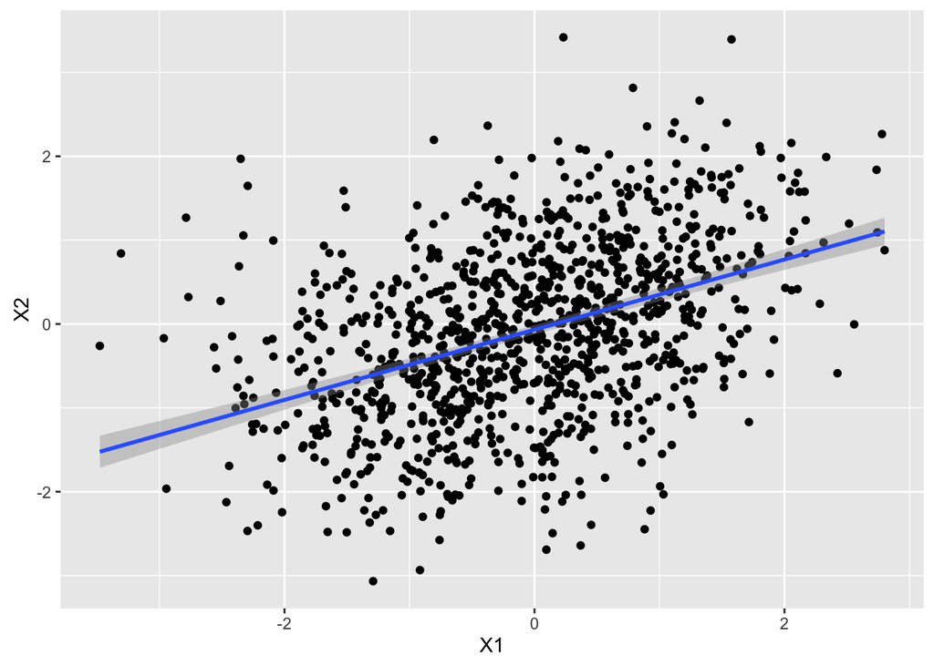

Population sample with linear fit

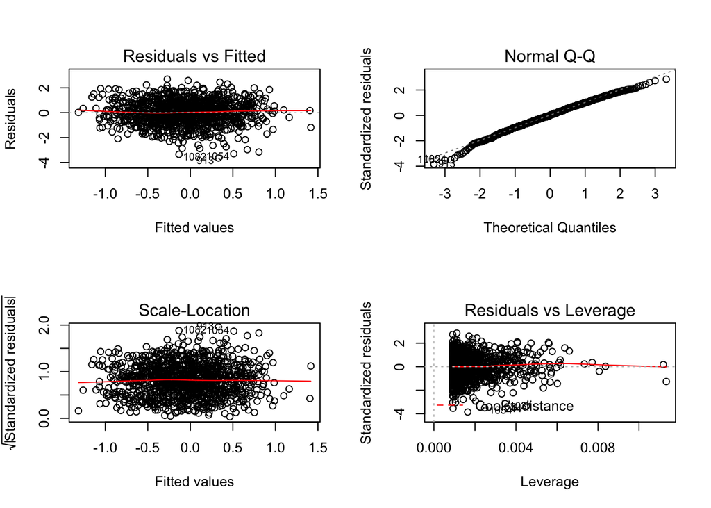

Residual plots look reasonable

If we didn’t suspect the existence of sub-populations, we might have stopped here. In fact, we know that this data was generated by combining 2 sub-groups into a single population.

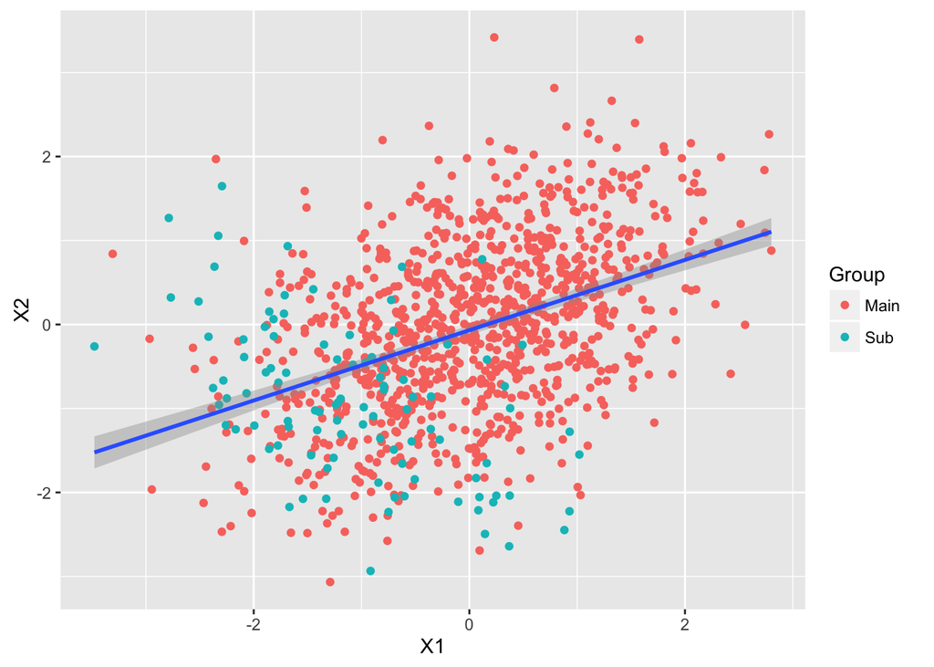

In reality, this ‘population’ is composed of 2 distinct sub-groups with opposite covariance between the predictor and response variables. One population is 10% of the size of the other.

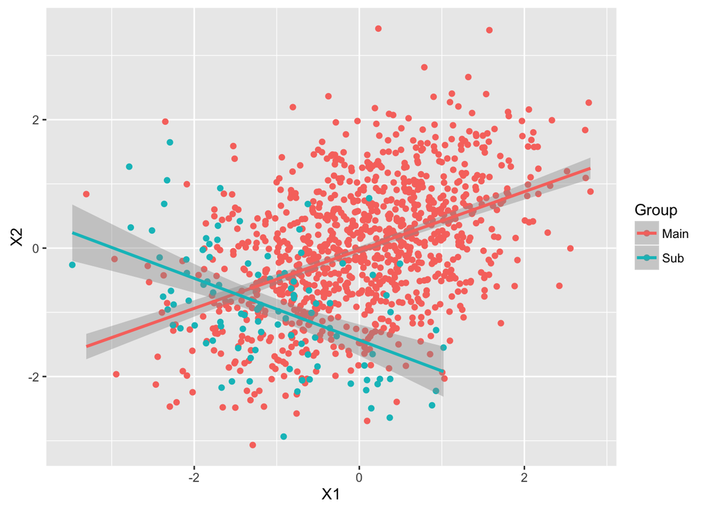

The linear fit for the larger sub-group is almost identical to the linear fit for the full population.

Notably, inference based on the first model without knowledge of the sub-groups might result in recommendations to increase X1 in order to improve our outcome X2. Such an increase would in fact be detrimental to the smaller sub-group, but overall would result in an improvement. Without knowing to look for sub-group effects across this particular type of sub-group, the researcher could end up making a recommendation that disadvantages the sub-population.

Some types of sub-populations: Ethnic group, socio-economic status, geographical, people who eat or don’t eat a type of food, users of specific medications, users of specific recreational drugs, people with specific medical conditions, people with a particular genetic mutation.

At root, this problem is due to an incorrect conceptual model underlying the analysis. But the point here is that the effect of the flawed model is effectively invisible to the researcher using diagnostic techniques currently available. The problem only becomse visible once we update the model to include the relevant sub-group, however there would be no reason to include the sub-group in data collection or modeling unless we have evidence leading us to believe that this sub-group is relevant. Evidence which can’t exist in a quantitative form until we have included the sub-group.

So if these types of sub-group problems can be completely invisible, then how are we to address them? Suggestions:

- Explicitly and critically model the process under study.
- Publish clear modeling assumptions for feedback and criticism. Other researchers with more knowledge of a particular sub-group or modeling sub-domain may be able to highlight possible sub-group issues.
- Pursue alternative approaches to the problem, including qualitative methods that may be better suited to identifying relevant sub-groups

An example: It is fairly well-known that compounds in grapefruit juice can interfere with the metabolism of certain types of statins. How was this discovered? … http://www.ncbi.nlm.nih.gov/pmc/articles/PMC2849981/

### Equity vs. Equality framework

More needs to be invested in disadvantaged people to bring them up to the same level as would need to be invested in a more advantaged person.

### Leverage

Example: It’s a lot easier to shop cheap if you can buy in bulk and store the food in your massive extra freezer than if you can’t even afford to have a refrigerator.